# Lesson 3

### What to Do First?

Notes:

```r
library(ggplot2)
```

### Pseudo-Facebook User Data

Notes:

```r
#list.files()
pf = read.csv('pseudo_facebook.tsv', sep = '\t')
#names(pf)
#summary(pf)
```

### Histogram of Users’ Birthdays

Notes:

Response: if two or more variable, use, facet_grid

Outliers/anomaly We may have to handle outliers differently depending our data. The data maybe accurate.accurate data in extereme case, like someone may definitely tweet thousands time a day. Or in other case,extreme valeu replace normal value. For example there’s top-coded data. Where people that have much larger income encoded in normal income in stackholder.

binwith =x is default descrete. It’s good to know that the average of people saw post in each of person expect is below their quarter friend_count

This is how we split the graph by gender, we subset our data to only include gender provided use eiher the case: data = subset(pf, !is.na(gender)) data =na.omit(pf)#Omit all the na values ***

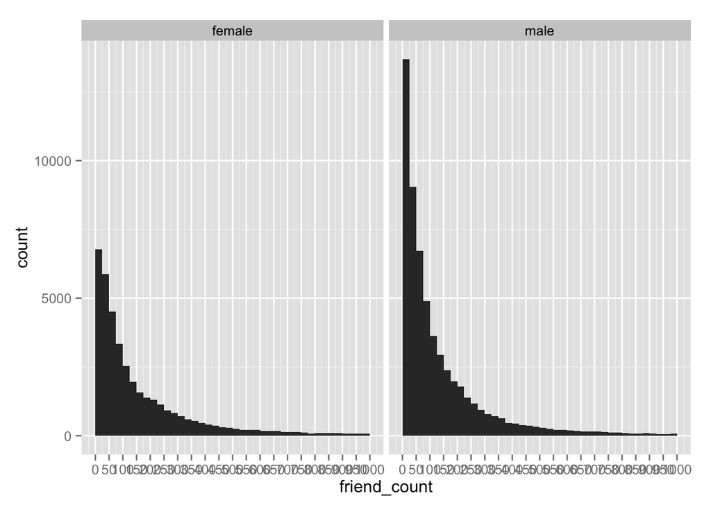

count man vs female Can also use by function takes categorical,list/indices,function

```r
#table(pf$gender)
by(pf$friend_count,pf$gender,summary)
```

```
## pf$gender: female
##    Min. 1st Qu.  Median    Mean 3rd Qu.    Max.
##       0      37      96     242     244    4923
## --------------------------------------------------------
## pf$gender: male
##    Min. 1st Qu.  Median    Mean 3rd Qu.    Max.
##       0      27      74     165     182    4917
```

The median of female is better than male, because the mean in female will drag the median lefwards of the graph. The median will resistance about the outliers(friend_count hight), because the average we can say that we at least try half of our data.

Adding the Color This graph will proceed as follows Tenure range from 1-365 days. in this case, we want to take range from 0 to 1 This will give us range histogram, to make it more convenience to see, we bulk(binwidth) it in 0.25

```r
#ggplot(aes(x = tenure/365), data =pf) + geom_histogram(binwidth = 0.25,color = 'black', fill = '#099DD9') + scale_x_continuous(breaks = seq(1,7,1) , limits = c(0,7))
```

Creating label

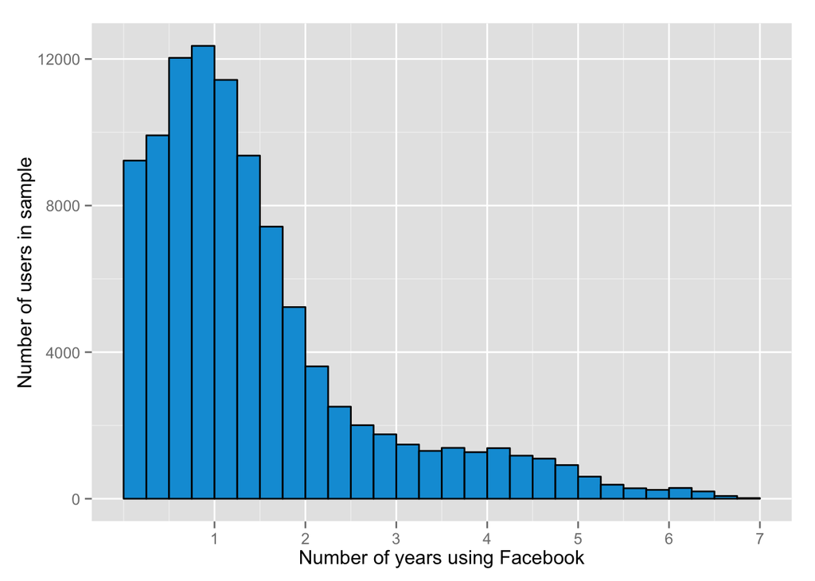

```r
ggplot(aes(x = tenure/365), data =pf) + geom_histogram(binwidth = 0.25,color = 'black', fill = '#099DD9') + scale_x_continuous(breaks = seq(1,7,1) , limits = c(0,7)) + xlab('Number of years using Facebook') + ylab('Number of users in sample')
```

create histogram of ages

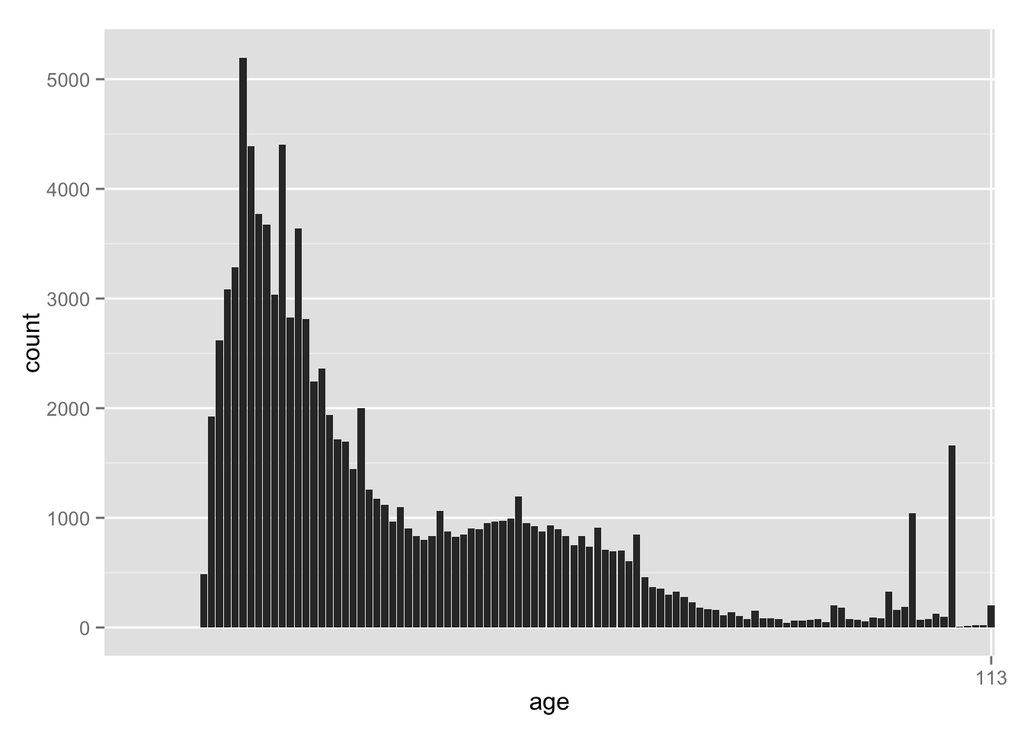

```r
ggplot(aes(x = age), data =pf) + geom_histogram(binwidth=1) + scale_x_discrete(breaks=c(0,113,5))
```

```r
#summary(pf$age)
#summary(pf$friend_count)
#summary(log10(pf$friend_count + 1))
```

For some people, they don’t have friend, so the baselog10 of zero(friend_count) = 0, this will get us -Inf which will disrupt our data. So to avoid this we increment all friend count by 1 Natural Log will set better normal distribution over outliers in our data Setting gridExtra

```
## stat_bin: binwidth defaulted to range/30. Use 'binwidth = x' to adjust this.
## stat_bin: binwidth defaulted to range/30. Use 'binwidth = x' to adjust this.
## stat_bin: binwidth defaulted to range/30. Use 'binwidth = x' to adjust this.
```

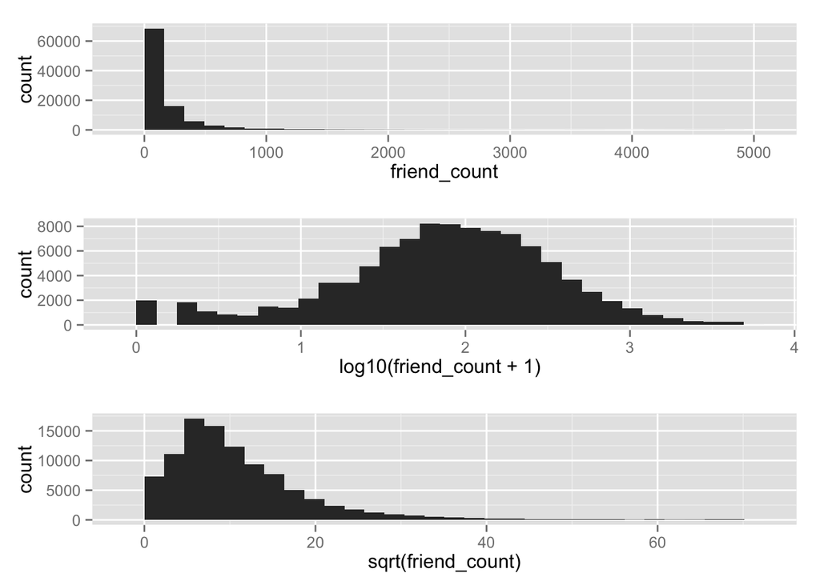

Another for doing different distribution

```r
#pl = ggplot(aes(x = friend_count), data = pf) + geom_histogram()
#pl2 = pl + scale_x_log10()
#pl3 = pl + scale_x_sqrt()
#grid.arrange(p1,p2,ncol=2)
```

```r
#countScale = ggplot(aes(x = log10(friend_count+1)), data = pf) + geom_histogram()
#logScale = pl2
#grid.arrange(countScale,logScale, ncol =2)
```

Coloring frequency polygon by gender

```
## stat_bin: binwidth defaulted to range/30. Use 'binwidth = x' to adjust this.
```

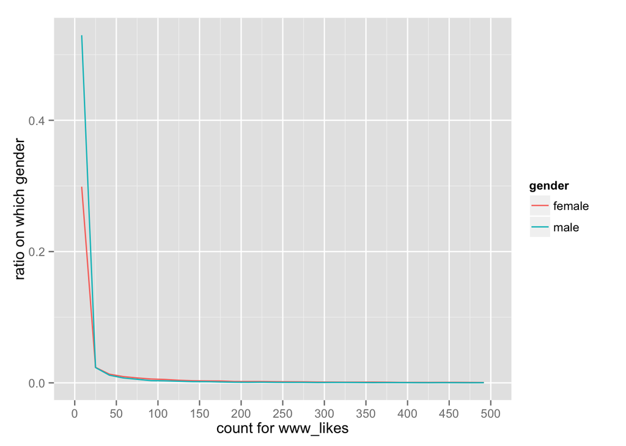

```r
ggplot(aes(x =www_likes, y = ..count../sum(..count..)),
       data = subset(pf, !is.na(gender))) + geom_freqpoly(aes(color = gender)) +
       scale_x_continuous(limits = c(0,500), breaks = seq(0,500,50))+
       xlab('count for www_likes') + ylab('ratio on which gender')
```

```r
#names(pf)
#summary(pf$www_likes)
#pf$www_likes
```

Compare the gender by who likes www_likes the most

```r
#summary(subset(pf,gender))
#table(pf$gender, pf$www_likes)
#table(pf$www_likes)
#count(pf)
by(pf$www_likes,pf$gender,sum)
```

```
## pf$gender: female
## [1] 3507665
## --------------------------------------------------------
## pf$gender: male
## [1] 1430175
```

### Box Plots, Quartiles, and Friendships

Notes: Boxplot use to plot the data with to know what are the range of min-q1-q2-q3-max in the sorting. By plotting this, we know the ouliers from each of the gender

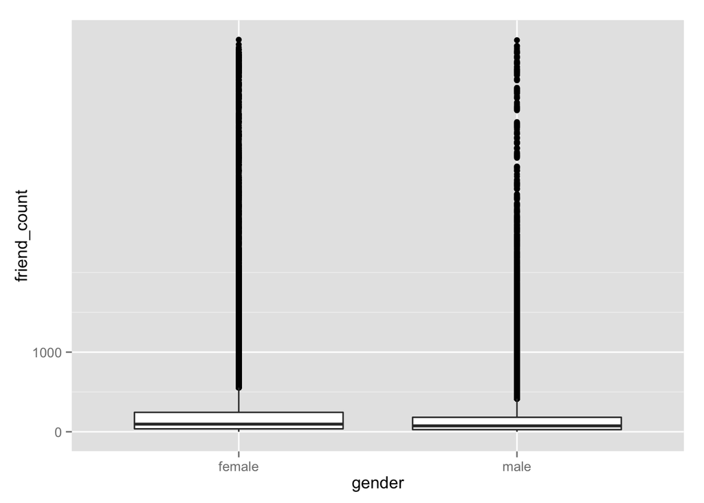

```r
ggplot(aes(y = friend_count, x = gender), data = subset(pf, !is.na(gender))) +
  geom_boxplot()  + scale_y_continuous(breaks = c(0,1000))
```

```r
#ggplot(aes(y = friend_count, x = gender), data = subset(pf, !is.na(gender))) +
#  geom_boxplot()  + coord_cartesian(ylim = c(0,1000))
```

#### On average, who initiated more friendships in our sample: men or women?

Response:Because the boxplot specify that most of women has higher max friend_count than men #### Write about some ways that you can verify your answer. Response:

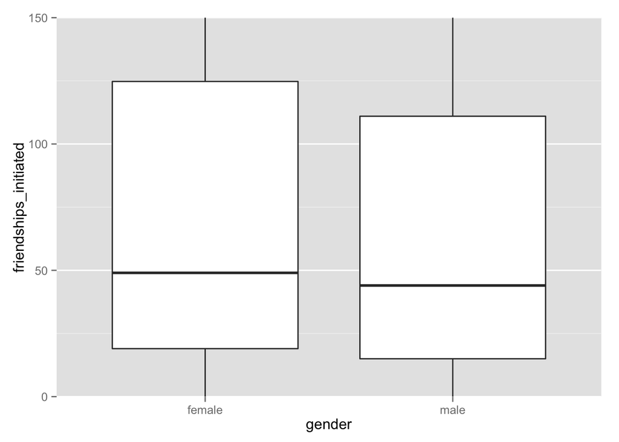

```r
ggplot(aes(y = friendships_initiated, x = gender), data = subset(pf, !is.na(gender))) +
  geom_boxplot()  + coord_cartesian(ylim = c(0,150))
```

```r
by(pf$friendships_initiated, pf$gender, summary)
```

```
## pf$gender: female
##    Min. 1st Qu.  Median    Mean 3rd Qu.    Max.
##     0.0    19.0    49.0   113.9   124.8  3654.0
## --------------------------------------------------------
## pf$gender: male
##    Min. 1st Qu.  Median    Mean 3rd Qu.    Max.
##     0.0    15.0    44.0   103.1   111.0  4144.0
```

Response: Boxplot should have more advange than mere by function summary split each of gender, because it gives us better sense how determining the outlier of data, and also the normal distribution ***

### Getting Logical

Notes: We can assign the new column, for this example assign 1 for user that using mobile(at least a like on mobile) With this we can actually create a new question. What are the ratio user using mobile

```r
summary(pf$mobile_likes > 0)
```

```
##    Mode   FALSE    TRUE    NA's
## logical   35056   63947       0
```

```r
#mobile_check_in <- NA
pf$mobile_check_in <- ifelse(pf$mobile_likes > 0, 1, 0)
pf$mobile_check_in <- factor(pf$mobile_check_in)
sum(pf$mobile_check_in == 1)/length(pf$mobile_check_in)
```

```
## [1] 0.6459097
```

```r
#sum(pf$gender)
#by(pf$mobile_check_in, pf$gender, sum)
sum(pf$mobile_likes)
```

```
## [1] 10505832
```

### Analyzing One Variable

Reflection: We understand a plotting and different kind of plotting. We transform our data to normalize distribution or synthesize it to another kind of data. ***

Click **KnitHTML** to see all of your hard work and to have an html page of this lesson, your answers, and your notes!